# (Chicago Crime Data Analysis and Visualization)

## by (Amr Morsy)

## Investigation Overview

> The goal of the presentation is to find the the rate of the crimes and get some information about the police and the crime rate in Chicago.

## Dataset Overview

> This dataset reflects reported incidents of crime (with the exception of murders where data exists for each victim) that occurred in the City of Chicago from 2004 to present

## (Crimes per year)

> The number of crimes decreases over year which means that police is going on the rightway. Also we should notice that 2005 is the most year that has crimes

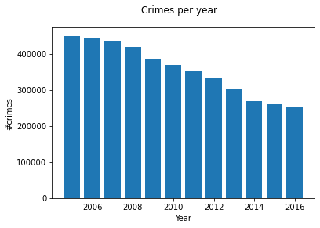

```python
x=allCrimes.groupby(allCrimes['Year'])['Year'].unique()
y=allCrimes.groupby(allCrimes['Year'])['ID'].count()

plt.bar(x, y)
plt.suptitle('Crimes per year')
# Labeling the axes
plt.xlabel('Year')
plt.ylabel('#crimes')

# Dsiplay the plot
plt.show()
```

## (Crime count)

> Theft and Battery are the most crime that happen in chicago over the years

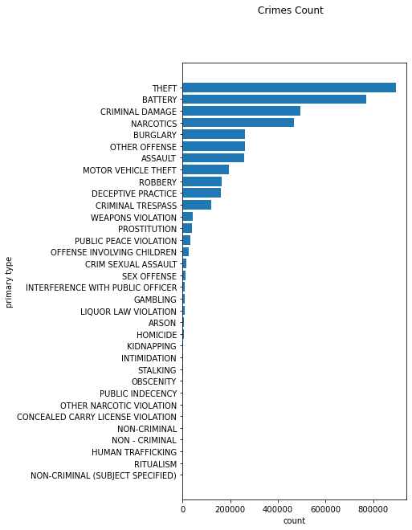

```python
val=(allCrimes['Primary Type']).value_counts (ascending=True)
x=val.index
y=val.values
plt.subplots(figsize=(5,10))
plt.barh(x, y)
#plt.invert_yaxis()
# Labeling the axes
plt.suptitle('Crimes Count')
plt.xlabel('count')
plt.ylabel('primary type')

# Dsiplay the plot
plt.show()
```

## (Number of Arrested)

> more than half of the crimiminals are not arrested ! the chicago police has to increase its efficiency

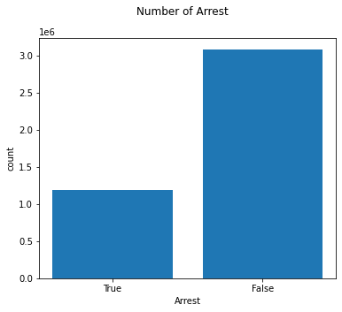

```python
val=(allCrimes['Arrest']).value_counts (ascending=True)
x=val.index
y=val.values
plt.subplots(figsize=(6,5))
plt.bar(x, y)
#plt.invert_yaxis()
# Labeling the axes
plt.suptitle('Number of Arrest')
plt.ylabel('count')
plt.xlabel('Arrest')

# Dsiplay the plot
plt.show()
```

## (Crime Rate per year)

> some of the crimes decreased throw time which mean the police is going in the right direction such as

> > Battery, Sex Offense, Prosttituion, public peace violation,offense, liquor law violation and Gambling

> But in some other crime there was a decreasing but since arround 2015 the crime started to increase such as

> > Robbery,motor vechile theft, Arson, Assual.

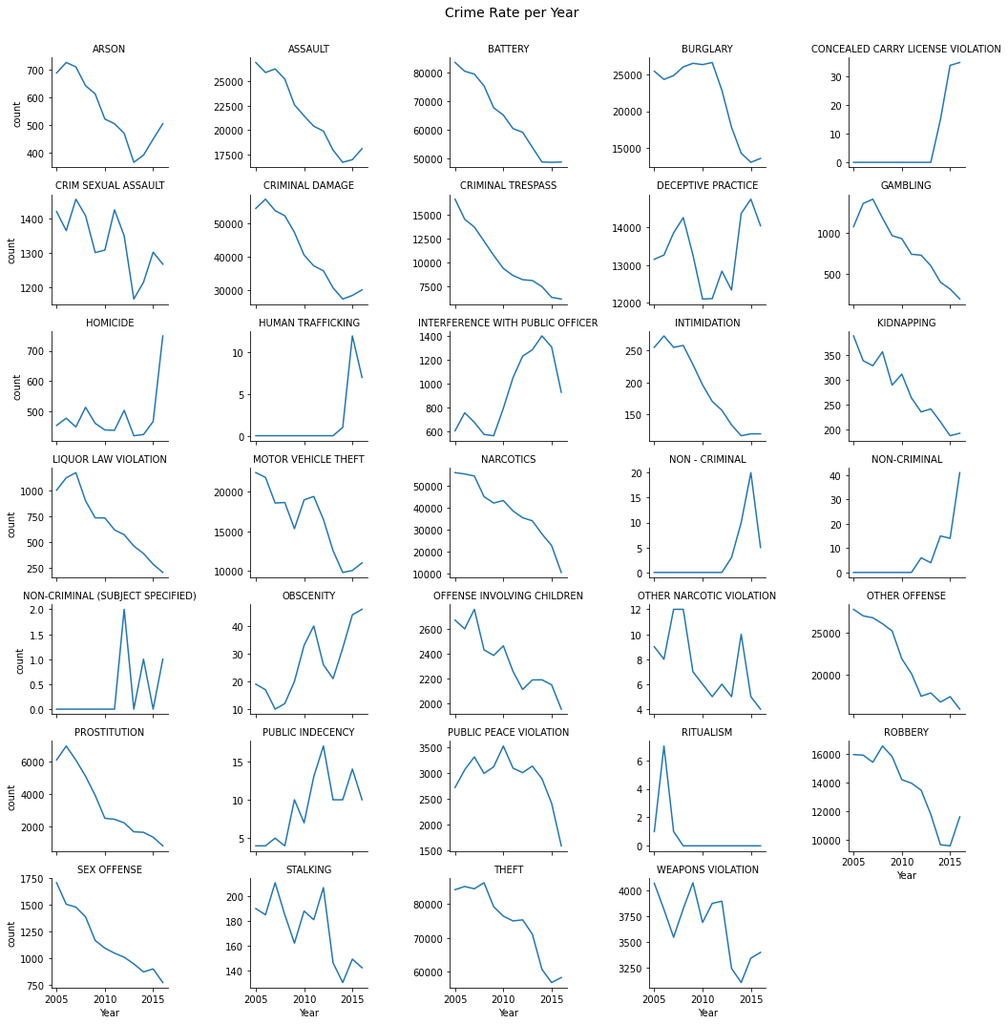

```python
crimes_counts = allCrimes.groupby(['Primary Type','Year']).size()
crimes_counts = crimes_counts.reset_index(name = 'count')

#fig, ax = plt.subplots(figsize=(10*10))
g = sb.FacetGrid(data = crimes_counts, col = 'Primary Type',col_wrap = 5,sharey = False)

g.map(sb.lineplot , "Year","count");

g.set_titles(row_template = '{row_name}', col_template = '{col_name}')
g.fig.suptitle("Crime Rate per Year", size=14)
g.fig.subplots_adjust(top=0.93)
g.fig.set_size_inches(15,15)
```